# Indo além do PCA, v2

Tarssio Barreto

21 de abril de 2019

## Pacotes que foram utilizados:

```r
#install.packages("pacman")
library(pacman)


p_load(caret, tidyverse, factoextra, epubr, tm, lexiconPT, broom, tidytext, widyr, irlba,
       Rtsne,plotly)

require(forcats)
```

## Pré-requisitos básicos:

### Carregando nossos dados:

```r
load("ThousandMiles.RData")
```

### Determinando nossas Stopwords:

```r
stop_words <- stopwords(kind = "pt") %>%
  as.tibble()
```

## Nosso Índice

O índice utilizado ele é representado pela divisão da probabilidade das duas palavras em questão estarem no mesmo twitter dividido pela probabilidade individual de cada uma destas palavras estarem presentes no total dos textos.

$$ptogether = \frac{p}{p1*p2}$$
Depois, reduziremos a quantidade de variáveis utilizando PCA e retornaremos 256 componentes príncipais. Desta forma, também mitigamos o efeito provocado pela correlação entre as palavras.

Por fim, reprojetaremos estas variáveis (utilizando os 256 PC´s) e para cada uma das palavras desejadas retornaremos aquelas que tem maior similidaridade. Similaridade, esta, que é uma transformação do index, dado os 256 componentes principais.

### Determinando a probabilidade individual:

Contamos então todas as palavras contidas nos twitters e retornamos a probabilidade individual desta, dada a totalidade dos nossos objetos de análise.

```r
unigram_probs <- df_tweets %>%
  tidytext::unnest_tokens(word, text, token = "tweets") %>%
  anti_join(stop_words, by= c("word" = "value")) %>%
  filter(!word %in% c("rt", "é", "vagas", "disponíveis", "286",
                      "adéli", "@makavelijones", "cristiane",
                      "=gt", "1", "2018", "sérgio", "mecan",
                      "3ª", "oi", "1406", "al", "el", "deyem",
                      "bey", "2", "100620019", "conv", "6")) %>%
  count(word, sort = TRUE) %>%
  mutate(p = n / sum(n)) %>%
  filter(str_detect(word, "@") == FALSE) %>%
  filter(str_detect(word, "https")== FALSE)

head(unigram_probs)
```

```
## # A tibble: 6 x 3
##   word               n       p
##   <chr>          <int>   <dbl>
## 1 #morocriminoso 32722 0.0389
## 2 moro           24170 0.0288
## 3 lula           12301 0.0146
## 4 #vazajato       7071 0.00841
## 5 dallagnol       6853 0.00815
## 6 juiz            6778 0.00806
```

### Determinando a probabilidade de duas palavras aparecerem juntas no mesmo tt:

Nesta etapa usaremos a função `pairwise` que retorna quantas vezes cada dupla de palavra apareceu juntas no mesmo objeto de análise:

```r
skipgram_probs <- df_tweets %>%
  tidytext::unnest_tokens(word, text, token = "tweets") %>%
  anti_join(stop_words, by= c("word" = "value")) %>%
  filter(!word %in% c("rt", "é", "vagas", "disponíveis", "286",
                      "adéli", "@makavelijones", "cristiane",
                      "=gt", "1", "2018", "sérgio", "mecan",
                      "3ª", "oi", "1406", "al", "el", "deyem",
                      "bey", "2", "10062019", "conv", "6")) %>%
  filter(str_detect(word, "@") == FALSE) %>%
  filter(str_detect(word, "https")== FALSE) %>%
  mutate(ngramID = id) %>%
  unite(skipgramID, ngramID) %>%
  widyr::pairwise_count(word, skipgramID, diag = TRUE, sort = TRUE) %>%
  dplyr::mutate(p = n / sum(n))
```

### Determinando nosso index:

Faremos então, o passo final, onde juntaremos as probabilidades inerentes a cada uma das parcelas e achararemos nosso `p_together` que é o indicador proposto acima

```r
index_prob <- skipgram_probs %>%
  dplyr::filter(n > 20) %>%
  dplyr::rename(word1 = item1, word2 = item2) %>%
  dplyr::left_join(unigram_probs %>%
                     select(word1 = word, p1 = p),
                   by = "word1") %>%
  dplyr::left_join(unigram_probs %>%
                     select(word2 = word, p2 = p),
                   by = "word2") %>%
  dplyr::mutate(p_together = p / p1 / p2)


head(index_prob)
```

```
## # A tibble: 6 x 7
##   word1          word2              n        p      p1      p2 p_together
##   <chr>          <chr>          <dbl>    <dbl>   <dbl>   <dbl>      <dbl>
## 1 #morocriminoso #morocriminoso 32429 0.00422  0.0389  0.0389        2.78
## 2 moro           moro           23602 0.00307  0.0288  0.0288        3.71
## 3 lula           lula           12045 0.00157  0.0146  0.0146        7.32
## 4 #vazajato      #vazajato       7019 0.000914 0.00841 0.00841      12.9
## 5 juiz           juiz            6658 0.000867 0.00806 0.00806      13.3
## 6 lula           moro            6287 0.000818 0.0146  0.0288        1.94
```

## PCA

Realizaremos o PCA dos nossos dados afim de reduzir a correlação entre as variáveis. Neste processo, transformaremos, primeiro, nossos dados em uma matriz esparsa e depois realizaremos o PCA de forma a ganhar processamento:

```r
pmi_matrix <- index_prob %>%
  dplyr::mutate(pmi = log10(p_together)) %>%
  tidytext::cast_sparse(word1, word2, pmi)

pmi_pca <- irlba::prcomp_irlba(pmi_matrix, n = 256)

word_vectors <- pmi_pca$x

rownames(word_vectors) <- rownames(pmi_matrix)
```

Usaremos, também, uma função `copiada` da Jesse para retornar os valores preditos para 256 PC´s. Esta função retorna as palavras mais similares a escolhida.

```r
search_synonyms <- function(word_vectors, selected_vector) {

  similarities <- word_vectors %*% selected_vector %>%
    tidy() %>%
    as_tibble() %>%
    rename(token = .rownames,
           similarity = unrowname.x.)

  similarities %>%
    arrange(-similarity)
}
```

## Criando gráficos:

### Gráfico das tags escolhidas:

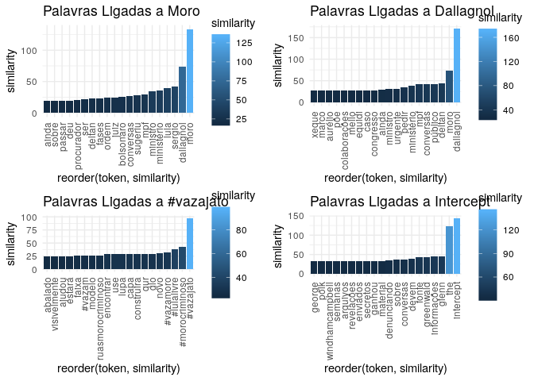

```r
p1 <- search_synonyms(word_vectors, word_vectors["moro",]) %>%
  top_n(20, abs(similarity)) %>%
  ggplot(aes(x = reorder(token, similarity), y = similarity,
             fill = similarity)) +
  geom_col() +
  theme_minimal() +
  theme(axis.text.x = element_text(angle = 90, hjust = 1, vjust = 0.5),
        axis.ticks.x = element_blank()) +
  labs(title = "Palavras Ligadas a Moro")

p2 <- search_synonyms(word_vectors, word_vectors["dallagnol",]) %>%
  top_n(20, abs(similarity)) %>%
  ggplot(aes(x = reorder(token, similarity), y = similarity,
             fill = similarity)) +
  geom_col() +
  theme_minimal() +
  theme(axis.text.x = element_text(angle = 90, hjust = 1, vjust = 0.5),
        axis.ticks.x = element_blank()) +
  labs(title = "Palavras Ligadas a Dallagnol")

p3 <- search_synonyms(word_vectors, word_vectors["#vazajato",]) %>%
  top_n(20, abs(similarity)) %>%
  ggplot(aes(x = reorder(token, similarity), y = similarity,
             fill = similarity)) +
  geom_col() +
  theme_minimal() +
  theme(axis.text.x = element_text(angle = 90, hjust = 1, vjust = 0.5),
        axis.ticks.x = element_blank()) +
  labs(title = "Palavras Ligadas a #vazajato")

p4 <- search_synonyms(word_vectors, word_vectors["intercept",]) %>%
  top_n(20, abs(similarity)) %>%
  ggplot(aes(x = reorder(token, similarity), y = similarity,
             fill = similarity)) +
  geom_col() +
  theme_minimal() +
  theme(axis.text.x = element_text(angle = 90, hjust = 1, vjust = 0.5),
        axis.ticks.x = element_blank()) +
  labs(title = "Palavras Ligadas a Intercept")


gridExtra::grid.arrange(p1,p2,p3,p4)
```

### Gráfico ligadas as eleições:

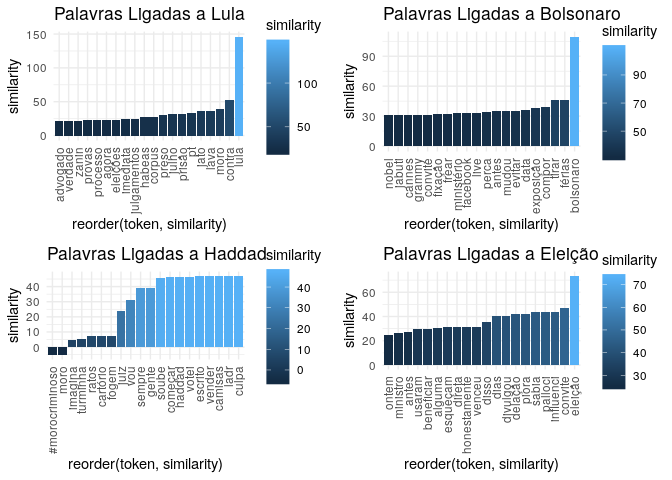

```r
p5 <- search_synonyms(word_vectors, word_vectors["lula",]) %>%
  top_n(20, abs(similarity)) %>%
  ggplot(aes(x = reorder(token, similarity), y = similarity,
             fill = similarity)) +
  geom_col() +
  theme_minimal() +
  theme(axis.text.x = element_text(angle = 90, hjust = 1, vjust = 0.5),
        axis.ticks.x = element_blank()) +
  labs(title = "Palavras Ligadas a Lula")

p6 <- search_synonyms(word_vectors, word_vectors["bolsonaro",]) %>%
  top_n(20, abs(similarity)) %>%
  ggplot(aes(x = reorder(token, similarity), y = similarity,
             fill = similarity)) +
  geom_col() +
  theme_minimal() +
  theme(axis.text.x = element_text(angle = 90, hjust = 1, vjust = 0.5),
        axis.ticks.x = element_blank()) +
  labs(title = "Palavras Ligadas a Bolsonaro")

p7 <- search_synonyms(word_vectors, word_vectors["haddad",]) %>%
  top_n(20, abs(similarity)) %>%
  ggplot(aes(x = reorder(token, similarity), y = similarity,
             fill = similarity)) +
  geom_col() +
  theme_minimal() +
  theme(axis.text.x = element_text(angle = 90, hjust = 1, vjust = 0.5),
        axis.ticks.x = element_blank()) +
  labs(title = "Palavras Ligadas a Haddad")

p8 <- search_synonyms(word_vectors, word_vectors["eleição",]) %>%
  top_n(20, abs(similarity)) %>%
  ggplot(aes(x = reorder(token, similarity), y = similarity,
             fill = similarity)) +
  geom_col() +
  theme_minimal() +
  theme(axis.text.x = element_text(angle = 90, hjust = 1, vjust = 0.5),
        axis.ticks.x = element_blank()) +
  labs(title = "Palavras Ligadas a Eleição")


gridExtra::grid.arrange(p5, p6, p7, p8)
```